# OHI regions — land and marine, 1 km

The grid is the marine region raster: Mexico ITRF2008 / LCC (EPSG:6372), 1 km cells, and the same extent and origin. A cell that already has a marine region number keeps it. A cell that the marine raster leaves empty is filled when its center falls inside a land polygon, using that polygon’s region number. Cells outside all nine regions stay empty.

The lookup table has one row per region: the number stored in the raster, the region name, the state, and the ecoregion. Land and marine of a region share those names. The table also records how many square kilometres of each region are marine and how many were filled from the land polygons.

```r
library(tidyverse)
library(terra)
library(sf)
library(knitr)
library(writexl)

knitr::opts_chunk$set(message = FALSE, warning = FALSE)

marine_path <- "/home/frazier/ohi_goc_prep/spatial/ohi_regions/ohi_marine_raster_1km.tif"
region_path <- "/home/frazier/ohi_goc_prep/spatial/ohi_regions/goc_ohi_rgns.shp"
out_dir <- "/home/frazier/ohi_goc_prep/spatial/marine_land_raster"
dir.create(out_dir, showWarnings = FALSE, recursive = TRUE)
```

## 1. The marine grid

Cell values in this raster are already the marine region numbers 1–9. Land and water outside the nine marine regions are empty. The combined raster is built on this object, so the two files share resolution, CRS, extent, and origin.

```r
marine <- rast(marine_path)
names(marine) <- "marine_id"

cat(
  "CRS:", crs(marine, describe = TRUE)$code, "\n",
  "Resolution, m:", paste(res(marine), collapse = " × "), "\n",
  "Rows × columns:", paste(dim(marine)[1:2], collapse = " × "), "\n",
  "Marine cells:", as.numeric(global(!is.na(marine), "sum", na.rm = TRUE)[1, 1]), "\n"
)
```

```
## CRS: 6372
##  Resolution, m: 1000 × 1000
##  Rows × columns: 1480 × 1250
##  Marine cells: 253228
```

## 2. Land polygons on the same grid

Land polygons carry the same `Region_1`–`Region_9` names as the marine polygons. The number written into a land cell is that region number. Rasterizing uses the cell center, which is the rule used for the marine raster. A land value is kept only where the marine raster is empty, so the marine numbers do not move.

```r
regions <- st_read(region_path, quiet = TRUE) %>%
  st_make_valid() %>%
  st_transform(crs(marine))

land <- regions %>%
  filter(location == "land") %>%
  mutate(rgn_num = as.integer(str_remove(rgn_id, "Region_")))

stopifnot(sort(unique(land$rgn_num)) == 1:9)

# Cell center inside a land polygon. Empty where the center is not on land.
land_id <- rasterize(vect(land), marine, field = "rgn_num", background = NA)
names(land_id) <- "land_id"

combined <- ifel(!is.na(marine), marine, land_id)
names(combined) <- "rgn_id"

# Every marine cell keeps the value from the marine raster.
marine_unchanged <- ifel(is.na(marine), 1, ifel(combined == marine, 1, 0))
stopifnot(as.numeric(global(marine_unchanged, "sum", na.rm = TRUE)[1, 1]) == ncell(marine))
stopifnot(compareGeom(combined, marine, stopOnError = FALSE))
```

## 3. Region lookup

One row per region number. `marine_km2` counts cells that were already in the marine raster. `land_km2` counts cells filled from the land polygons. Each 1 km cell is 1 km².

```r
region_info <- regions %>%
  st_drop_geometry() %>%
  filter(location == "marine") %>%
  transmute(
    id = as.integer(id),
    rgn_id = rgn_id,
    estado = estado,
    ecorgn = ecorgn,
    region_label = paste(
      rgn_id,
      str_replace_all(estado, "_", " "),
      str_replace_all(ecorgn, "_", " "),
      sep = " · "
    )
  ) %>%
  arrange(id)

# Land contribution: combined id where the marine raster was empty.
land_cells <- ifel(is.na(marine), combined, NA)
area_cells <- c(marine, land_cells)
names(area_cells) <- c("marine_id", "land_id")

area_by_id <- as.data.frame(area_cells, na.rm = FALSE) %>%
  pivot_longer(everything(), names_to = "part", values_to = "id") %>%
  filter(!is.na(id)) %>%
  count(id, part, name = "km2") %>%
  pivot_wider(names_from = part, values_from = km2, values_fill = 0) %>%
  rename(marine_km2 = marine_id, land_km2 = land_id)

region_table <- region_info %>%
  left_join(area_by_id, by = "id") %>%
  mutate(
    marine_km2 = replace_na(marine_km2, 0),
    land_km2 = replace_na(land_km2, 0),
    total_km2 = marine_km2 + land_km2
  )

kable(
  region_table %>%
    select(id, rgn_id, estado, ecorgn, marine_km2, land_km2, total_km2),
  digits = 0,
  col.names = c("Raster id", "Region", "State", "Ecoregion", "Marine, km²", "Land, km²", "Total, km²"),
  caption = "Region attributes for the land-and-marine raster. The raster id is the same on land and on the water."
)
```

Region attributes for the land-and-marine raster. The raster id is the same on land and on the water.

| Raster id | Region | State | Ecoregion | Marine, km² | Land, km² | Total, km² |
| --- | --- | --- | --- | --- | --- | --- |
| 1 | Region_1 | Baja_California | Upper_Gulf | 2426 | 35117 | 37543 |
| 2 | Region_2 | Baja_California | Midriff_Region | 27251 | 38112 | 65363 |
| 3 | Region_3 | Baja_California_Sur | Central_Gulf | 16490 | 36436 | 52926 |
| 4 | Region_4 | Baja_California_Sur | Southern_Gulf | 105140 | 37198 | 142338 |
| 5 | Region_5 | Sonora | Upper_Gulf | 3397 | 18201 | 21598 |
| 6 | Region_6 | Sonora | Midriff_Region | 24695 | 110602 | 135297 |
| 7 | Region_7 | Sonora | Central_Gulf | 20316 | 51516 | 71832 |
| 8 | Region_8 | Sinaloa | Southern_Gulf | 28918 | 54813 | 83731 |
| 9 | Region_9 | Nayarit | Southern_Gulf | 24595 | 44802 | 69397 |

```r
write_csv(region_table, file.path(out_dir, "ohi_regions_land_marine.csv"))
write_xlsx(region_table, file.path(out_dir, "ohi_regions_land_marine.xlsx"))
```

## 4. Map

Each color is one region, on land and on the water.

```r
rgn_colors <- c(
  "Region 1" = "#C03729",
  "Region 2" = "#E68C7C",
  "Region 3" = "#FC8F24",
  "Region 4" = "#dcaa38",
  "Region 5" = "#cbd2a0",
  "Region 6" = "#98a25a",
  "Region 7" = "#747428",
  "Region 8" = "#627391",
  "Region 9" = "#8d61a9"
)

map_df <- as.data.frame(combined, xy = TRUE, na.rm = TRUE)
names(map_df)[3] <- "id"
map_df <- map_df %>%
  left_join(region_info %>% select(id, rgn_id), by = "id") %>%
  mutate(
    region_label = factor(
      str_replace(rgn_id, "_", " "),
      levels = names(rgn_colors)
    )
  )
```

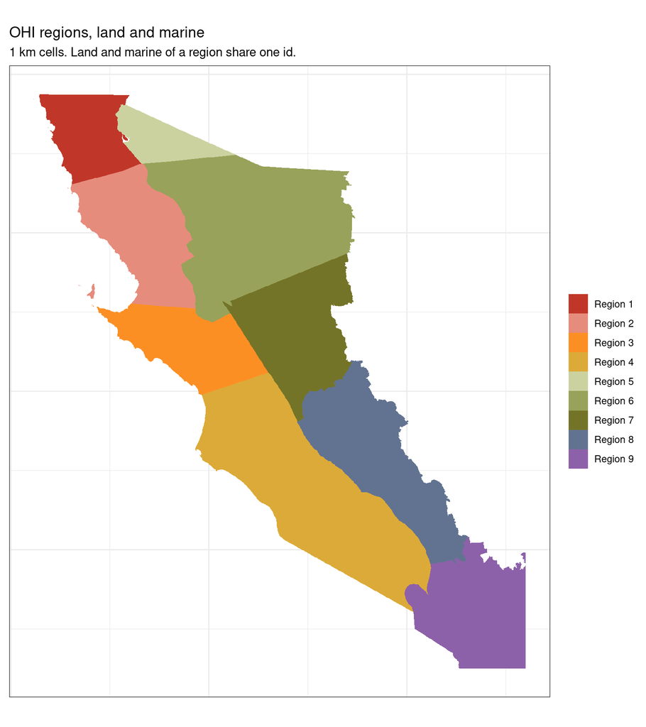

```r
region_plot <- ggplot(map_df, aes(x, y, fill = region_label)) +
  geom_raster() +
  scale_fill_manual(values = rgn_colors, name = NULL) +
  coord_equal() +
  labs(
    title = "OHI regions, land and marine",
    subtitle = "1 km cells. Land and marine of a region share one id.",
    x = NULL,
    y = NULL
  ) +
  theme_bw() +
  theme(axis.text = element_blank(), axis.ticks = element_blank())

print(region_plot)
```

```r
ggsave(
  file.path(out_dir, "ohi_land_marine_regions_1km.png"),
  region_plot,
  width = 8,
  height = 9,
  dpi = 150,
  bg = "white"
)
```

## 5. Saved raster

Values are the region numbers 1–9. Empty cells are outside the nine regions. Where the marine raster has a value, this raster has the same value.

```r
raster_path <- file.path(out_dir, "ohi_land_marine_raster_1km.tif")
writeRaster(combined, raster_path, overwrite = TRUE, datatype = "INT1U", NAflag = 255)

cat("Raster:", raster_path, "\n")
```

```
## Raster: /home/frazier/ohi_goc_prep/spatial/marine_land_raster/ohi_land_marine_raster_1km.tif
```

```r
cat("Lookup:", file.path(out_dir, "ohi_regions_land_marine.xlsx"), "\n")
```

```
## Lookup: /home/frazier/ohi_goc_prep/spatial/marine_land_raster/ohi_regions_land_marine.xlsx
```

```r
cat("File, KB:", round(file.size(raster_path) / 1024), "\n")
```

```
## File, KB: 64
```

```r
cat(
  "Cells with a region id:",
  as.numeric(global(!is.na(combined), "sum", na.rm = TRUE)[1, 1]), "\n"
)
```

```
## Cells with a region id: 680025
```

The raster is /home/frazier/ohi_goc_prep/spatial/marine_land_raster/ohi_land_marine_raster_1km.tif.